# INSTALLING DEPENDENCIES

```python
#-------------------------INSTALLING DEPENDENICIES-------------------------

!pip install catboost
!pip install shap
!pip install xgboost
```

# IMPORTING DEPENDENCIES

```python
#-------------------------IMPORTING DEPENDENICIES-------------------------

import pandas as pd
import matplotlib as mat
import matplotlib.pyplot as plt
import numpy as np
import seaborn as sns
%matplotlib inline

from sklearn.model_selection import train_test_split
from sklearn import metrics
from sklearn.preprocessing import LabelEncoder

from sklearn.ensemble import RandomForestClassifier
from catboost import CatBoostClassifier
from catboost import Pool

import shap

import warnings
warnings.filterwarnings('ignore')
```

# DATA INTAKE AND DATA SCRUBBING

```python
import os
os.chdir("A:\Study Materials\Credit Card Default")
```

```python
#-------------------------DATA INTAKE-------------------------

df = pd.read_csv(os.getcwd() + '/Data/UCI_Credit_Card.csv', index_col = 'ID')
```

```python
df.head()
```

| ID | LIMIT_BAL | SEX | EDUCATION | MARRIAGE | AGE | PAY_0 | PAY_2 | PAY_3 | PAY_4 | PAY_5 | ... | BILL_AMT4 | BILL_AMT5 | BILL_AMT6 | PAY_AMT1 | PAY_AMT2 | PAY_AMT3 | PAY_AMT4 | PAY_AMT5 | PAY_AMT6 | default.payment.next.month |
| --- | --- | --- | --- | --- | --- | --- | --- | --- | --- | --- | --- | --- | --- | --- | --- | --- | --- | --- | --- | --- | --- |
| 1 | 20000.0 | 2 | 2 | 1 | 24 | 2 | 2 | -1 | -1 | -2 | ... | 0.0 | 0.0 | 0.0 | 0.0 | 689.0 | 0.0 | 0.0 | 0.0 | 0.0 | 1 |
| 2 | 120000.0 | 2 | 2 | 2 | 26 | -1 | 2 | 0 | 0 | 0 | ... | 3272.0 | 3455.0 | 3261.0 | 0.0 | 1000.0 | 1000.0 | 1000.0 | 0.0 | 2000.0 | 1 |
| 3 | 90000.0 | 2 | 2 | 2 | 34 | 0 | 0 | 0 | 0 | 0 | ... | 14331.0 | 14948.0 | 15549.0 | 1518.0 | 1500.0 | 1000.0 | 1000.0 | 1000.0 | 5000.0 | 0 |
| 4 | 50000.0 | 2 | 2 | 1 | 37 | 0 | 0 | 0 | 0 | 0 | ... | 28314.0 | 28959.0 | 29547.0 | 2000.0 | 2019.0 | 1200.0 | 1100.0 | 1069.0 | 1000.0 | 0 |
| 5 | 50000.0 | 1 | 2 | 1 | 57 | -1 | 0 | -1 | 0 | 0 | ... | 20940.0 | 19146.0 | 19131.0 | 2000.0 | 36681.0 | 10000.0 | 9000.0 | 689.0 | 679.0 | 0 |

5 rows × 24 columns

LETS START DATA SCRUBBING :

```python
#-------------------------DATA DISTRIBUTION AND RELATED PROPERTIES-------------------------

df.describe(include= 'all')
```

|  | LIMIT_BAL | SEX | EDUCATION | MARRIAGE | AGE | PAY_0 | PAY_2 | PAY_3 | PAY_4 | PAY_5 | ... | BILL_AMT4 | BILL_AMT5 | BILL_AMT6 | PAY_AMT1 | PAY_AMT2 | PAY_AMT3 | PAY_AMT4 | PAY_AMT5 | PAY_AMT6 | default.payment.next.month |
| --- | --- | --- | --- | --- | --- | --- | --- | --- | --- | --- | --- | --- | --- | --- | --- | --- | --- | --- | --- | --- | --- |
| count | 30000.000000 | 30000.000000 | 30000.000000 | 30000.000000 | 30000.000000 | 30000.000000 | 30000.000000 | 30000.000000 | 30000.000000 | 30000.000000 | ... | 30000.000000 | 30000.000000 | 30000.000000 | 30000.000000 | 3.000000e+04 | 30000.00000 | 30000.000000 | 30000.000000 | 30000.000000 | 30000.000000 |
| mean | 167484.322667 | 1.603733 | 1.853133 | 1.551867 | 35.485500 | -0.016700 | -0.133767 | -0.166200 | -0.220667 | -0.266200 | ... | 43262.948967 | 40311.400967 | 38871.760400 | 5663.580500 | 5.921163e+03 | 5225.68150 | 4826.076867 | 4799.387633 | 5215.502567 | 0.221200 |
| std | 129747.661567 | 0.489129 | 0.790349 | 0.521970 | 9.217904 | 1.123802 | 1.197186 | 1.196868 | 1.169139 | 1.133187 | ... | 64332.856134 | 60797.155770 | 59554.107537 | 16563.280354 | 2.304087e+04 | 17606.96147 | 15666.159744 | 15278.305679 | 17777.465775 | 0.415062 |
| min | 10000.000000 | 1.000000 | 0.000000 | 0.000000 | 21.000000 | -2.000000 | -2.000000 | -2.000000 | -2.000000 | -2.000000 | ... | -170000.000000 | -81334.000000 | -339603.000000 | 0.000000 | 0.000000e+00 | 0.00000 | 0.000000 | 0.000000 | 0.000000 | 0.000000 |
| 25% | 50000.000000 | 1.000000 | 1.000000 | 1.000000 | 28.000000 | -1.000000 | -1.000000 | -1.000000 | -1.000000 | -1.000000 | ... | 2326.750000 | 1763.000000 | 1256.000000 | 1000.000000 | 8.330000e+02 | 390.00000 | 296.000000 | 252.500000 | 117.750000 | 0.000000 |
| 50% | 140000.000000 | 2.000000 | 2.000000 | 2.000000 | 34.000000 | 0.000000 | 0.000000 | 0.000000 | 0.000000 | 0.000000 | ... | 19052.000000 | 18104.500000 | 17071.000000 | 2100.000000 | 2.009000e+03 | 1800.00000 | 1500.000000 | 1500.000000 | 1500.000000 | 0.000000 |
| 75% | 240000.000000 | 2.000000 | 2.000000 | 2.000000 | 41.000000 | 0.000000 | 0.000000 | 0.000000 | 0.000000 | 0.000000 | ... | 54506.000000 | 50190.500000 | 49198.250000 | 5006.000000 | 5.000000e+03 | 4505.00000 | 4013.250000 | 4031.500000 | 4000.000000 | 0.000000 |
| max | 1000000.000000 | 2.000000 | 6.000000 | 3.000000 | 79.000000 | 8.000000 | 8.000000 | 8.000000 | 8.000000 | 8.000000 | ... | 891586.000000 | 927171.000000 | 961664.000000 | 873552.000000 | 1.684259e+06 | 896040.00000 | 621000.000000 | 426529.000000 | 528666.000000 | 1.000000 |

8 rows × 24 columns

```python
#-------------------------LET's RENAME THE ATTRIBUTES TO FOLLOW A GENERAL PATTERN-------------------------

df.rename(columns = {'PAY_0':'PAY_1', 'default.payment.next.month':'Default'}, inplace = True)
```

```python
df.head()
```

| ID | LIMIT_BAL | SEX | EDUCATION | MARRIAGE | AGE | PAY_1 | PAY_2 | PAY_3 | PAY_4 | PAY_5 | ... | BILL_AMT4 | BILL_AMT5 | BILL_AMT6 | PAY_AMT1 | PAY_AMT2 | PAY_AMT3 | PAY_AMT4 | PAY_AMT5 | PAY_AMT6 | Default |
| --- | --- | --- | --- | --- | --- | --- | --- | --- | --- | --- | --- | --- | --- | --- | --- | --- | --- | --- | --- | --- | --- |
| 1 | 20000.0 | 2 | 2 | 1 | 24 | 2 | 2 | -1 | -1 | -2 | ... | 0.0 | 0.0 | 0.0 | 0.0 | 689.0 | 0.0 | 0.0 | 0.0 | 0.0 | 1 |
| 2 | 120000.0 | 2 | 2 | 2 | 26 | -1 | 2 | 0 | 0 | 0 | ... | 3272.0 | 3455.0 | 3261.0 | 0.0 | 1000.0 | 1000.0 | 1000.0 | 0.0 | 2000.0 | 1 |
| 3 | 90000.0 | 2 | 2 | 2 | 34 | 0 | 0 | 0 | 0 | 0 | ... | 14331.0 | 14948.0 | 15549.0 | 1518.0 | 1500.0 | 1000.0 | 1000.0 | 1000.0 | 5000.0 | 0 |
| 4 | 50000.0 | 2 | 2 | 1 | 37 | 0 | 0 | 0 | 0 | 0 | ... | 28314.0 | 28959.0 | 29547.0 | 2000.0 | 2019.0 | 1200.0 | 1100.0 | 1069.0 | 1000.0 | 0 |
| 5 | 50000.0 | 1 | 2 | 1 | 57 | -1 | 0 | -1 | 0 | 0 | ... | 20940.0 | 19146.0 | 19131.0 | 2000.0 | 36681.0 | 10000.0 | 9000.0 | 689.0 | 679.0 | 0 |

5 rows × 24 columns

```python
#-------------------------CHECKING DATATYPES AND NOT NULL COUNTS FOR EACH-------------------------

df.info()
```

```
<class 'pandas.core.frame.DataFrame'>
Int64Index: 30000 entries, 1 to 30000
Data columns (total 24 columns):
 #   Column     Non-Null Count  Dtype
---  ------     --------------  -----
 0   LIMIT_BAL  30000 non-null  float64
 1   SEX        30000 non-null  int64
 2   EDUCATION  30000 non-null  int64
 3   MARRIAGE   30000 non-null  int64
 4   AGE        30000 non-null  int64
 5   PAY_1      30000 non-null  int64
 6   PAY_2      30000 non-null  int64
 7   PAY_3      30000 non-null  int64
 8   PAY_4      30000 non-null  int64
 9   PAY_5      30000 non-null  int64
```

[output cut: 16 more lines]

# EXPLORATORY DATA ANALYSIS

LETS TRY DATA EXPLORATION FROM HERE

```python
df.describe().T
```

|  | count | mean | std | min | 25% | 50% | 75% | max |
| --- | --- | --- | --- | --- | --- | --- | --- | --- |
| LIMIT_BAL | 30000.0 | 167484.322667 | 129747.661567 | 10000.0 | 50000.00 | 140000.0 | 240000.00 | 1000000.0 |
| SEX | 30000.0 | 1.603733 | 0.489129 | 1.0 | 1.00 | 2.0 | 2.00 | 2.0 |
| EDUCATION | 30000.0 | 1.853133 | 0.790349 | 0.0 | 1.00 | 2.0 | 2.00 | 6.0 |
| MARRIAGE | 30000.0 | 1.551867 | 0.521970 | 0.0 | 1.00 | 2.0 | 2.00 | 3.0 |
| AGE | 30000.0 | 35.485500 | 9.217904 | 21.0 | 28.00 | 34.0 | 41.00 | 79.0 |
| PAY_1 | 30000.0 | -0.016700 | 1.123802 | -2.0 | -1.00 | 0.0 | 0.00 | 8.0 |
| PAY_2 | 30000.0 | -0.133767 | 1.197186 | -2.0 | -1.00 | 0.0 | 0.00 | 8.0 |
| PAY_3 | 30000.0 | -0.166200 | 1.196868 | -2.0 | -1.00 | 0.0 | 0.00 | 8.0 |
| PAY_4 | 30000.0 | -0.220667 | 1.169139 | -2.0 | -1.00 | 0.0 | 0.00 | 8.0 |
| PAY_5 | 30000.0 | -0.266200 | 1.133187 | -2.0 | -1.00 | 0.0 | 0.00 | 8.0 |
| PAY_6 | 30000.0 | -0.291100 | 1.149988 | -2.0 | -1.00 | 0.0 | 0.00 | 8.0 |
| BILL_AMT1 | 30000.0 | 51223.330900 | 73635.860576 | -165580.0 | 3558.75 | 22381.5 | 67091.00 | 964511.0 |
| BILL_AMT2 | 30000.0 | 49179.075167 | 71173.768783 | -69777.0 | 2984.75 | 21200.0 | 64006.25 | 983931.0 |
| BILL_AMT3 | 30000.0 | 47013.154800 | 69349.387427 | -157264.0 | 2666.25 | 20088.5 | 60164.75 | 1664089.0 |
| BILL_AMT4 | 30000.0 | 43262.948967 | 64332.856134 | -170000.0 | 2326.75 | 19052.0 | 54506.00 | 891586.0 |
| BILL_AMT5 | 30000.0 | 40311.400967 | 60797.155770 | -81334.0 | 1763.00 | 18104.5 | 50190.50 | 927171.0 |
| BILL_AMT6 | 30000.0 | 38871.760400 | 59554.107537 | -339603.0 | 1256.00 | 17071.0 | 49198.25 | 961664.0 |
| PAY_AMT1 | 30000.0 | 5663.580500 | 16563.280354 | 0.0 | 1000.00 | 2100.0 | 5006.00 | 873552.0 |
| PAY_AMT2 | 30000.0 | 5921.163500 | 23040.870402 | 0.0 | 833.00 | 2009.0 | 5000.00 | 1684259.0 |
| PAY_AMT3 | 30000.0 | 5225.681500 | 17606.961470 | 0.0 | 390.00 | 1800.0 | 4505.00 | 896040.0 |
| PAY_AMT4 | 30000.0 | 4826.076867 | 15666.159744 | 0.0 | 296.00 | 1500.0 | 4013.25 | 621000.0 |
| PAY_AMT5 | 30000.0 | 4799.387633 | 15278.305679 | 0.0 | 252.50 | 1500.0 | 4031.50 | 426529.0 |
| PAY_AMT6 | 30000.0 | 5215.502567 | 17777.465775 | 0.0 | 117.75 | 1500.0 | 4000.00 | 528666.0 |
| Default | 30000.0 | 0.221200 | 0.415062 | 0.0 | 0.00 | 0.0 | 0.00 | 1.0 |

1. COUNTPLOT ( OUTPUT DISTRIBUTION )

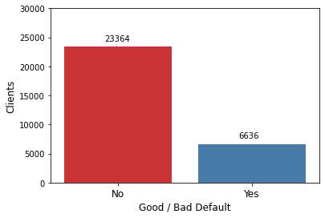

```python
plt.figure(figsize=(6,4))

ax = sns.countplot(x="Default", data=df, palette="Set1")

plt.xlabel("Good / Bad Default", fontsize= 12)
plt.ylabel("Clients", fontsize= 12)
plt.ylim(0,30000)
plt.xticks([0,1], ['No', 'Yes'], fontsize = 12)

for p in ax.patches:
    ax.annotate((p.get_height()), (p.get_x()+0.30, p.get_height()+1000))

plt.show()
```

1. PIE CHART (OUTPUT DISTRIBUTION)

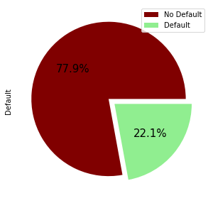

```python
plt.figure(figsize=(5,5))

df['Default'].value_counts().plot(kind='pie',labels = ['',''], autopct='%1.1f%%', colors = ['maroon','lightgreen'], explode = [0.05,0.05], textprops = {"fontsize":15})

plt.legend(labels=['No Default', 'Default'])
plt.show()
```

> LET CHECK CORRELATIONS:

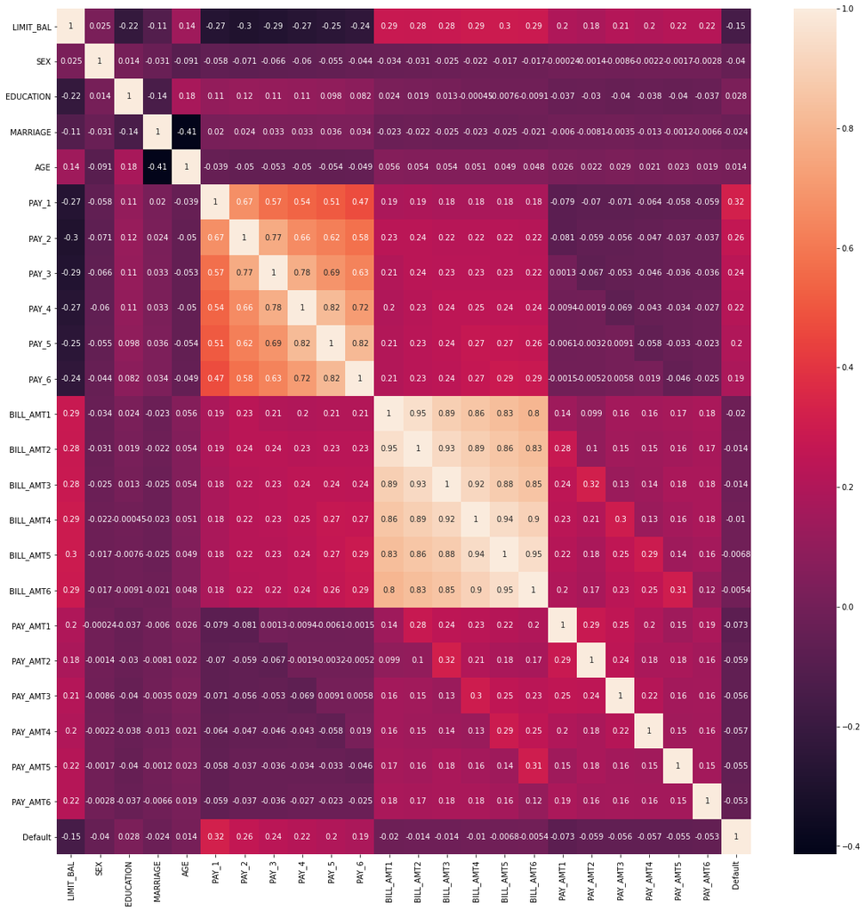

```python
correlations = df.corr()
f, ax = plt.subplots(figsize=(20,20))
sns.heatmap(correlations, annot=True)
```

NOW LETS START PLOTTING ATTRIBUTES

1. SEX V/S DEFAULT

```python
df['SEX'].value_counts()
```

```
2    18112
1    11888
Name: SEX, dtype: int64
```

> DATA DISTRIBUTION

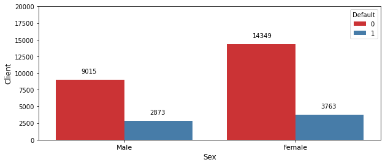

```python
plt.figure(figsize=(10,4))

ax = sns.countplot(data = df, x = 'SEX', hue="Default", palette = 'Set1')

plt.xlabel("Sex", fontsize= 12)
plt.ylabel("Client", fontsize= 12)
plt.ylim(0,20000)
plt.xticks([0,1],['Male', 'Female'], fontsize = 11)

for p in ax.patches:
    ax.annotate((p.get_height()), (p.get_x()+0.15, p.get_height()+1000))

plt.show()
```

```python
df['Default'].groupby(df['SEX']).value_counts(normalize = True)
```

```
SEX  Default
1    0          0.758328
     1          0.241672
2    0          0.792237
     1          0.207763
Name: Default, dtype: float64
```

> DATA DENSITY

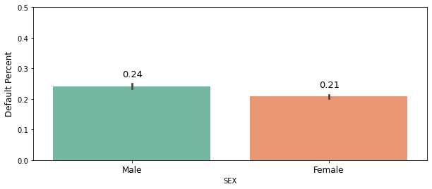

```python
plt.figure(figsize=(10,4))

ax = sns.barplot(x = "SEX", y = "Default", data = df, palette = 'Set2')

plt.ylabel("Default Percent", fontsize= 12)
plt.ylim(0,0.5)
plt.xticks([0,1],['Male', 'Female'], fontsize = 12)

for p in ax.patches:
    ax.annotate("%.2f" %(p.get_height()), (p.get_x()+0.35, p.get_height()+0.03),fontsize=13)

plt.show()
```

OUTCOMES FROM PLOTS AND DATA SCRUBBING:

- It seems to have more women than men in our dataset and, apparently, men may have a slightly higher chance of default.
- Also, the Education Attribute seem to be somewhat unbiased hence, partially able to corrupt output as, according to DB it says, '4' ressemble to 'others' but eventually there are data with (0, 5, 6) with no label mentioned

REMEDIES TO BE TRIED:

- We can try listing Education values --> (0,4,5,6) under same category as 'others'
- As 5,6 values are originally referred to UNKNOWN and O has no ressemblance.

> But before that lets see, how many such case are existing and see the distribution overall

EDUCATION V/S DEFAULT

```python
df['EDUCATION'].value_counts()
```

```
2    14030
1    10585
3     4917
5      280
4      123
6       51
0       14
Name: EDUCATION, dtype: int64
```

```python
df['Default'].groupby(df['EDUCATION']).value_counts(normalize = True)
```

```
EDUCATION  Default
0          0          1.000000
1          0          0.807652
           1          0.192348
2          0          0.762651
           1          0.237349
3          0          0.748424
           1          0.251576
4          0          0.943089
           1          0.056911
5          0          0.935714
           1          0.064286
6          0          0.843137
           1          0.156863
Name: Default, dtype: float64
```

There are few people on the 'unknown' categories (0, 5, 6) I'll be making the choice of putting them together with the same value.

> Although their probabilities of default not lie in a closer range, I will go with the remedy I proposed earlier

> As, the probability is comparatively very less to the Defined Labels.

```python
df.loc[:,'EDUCATION'] = df.loc[:,'EDUCATION'].replace(0,5)
df.loc[:,'EDUCATION'] = df.loc[:,'EDUCATION'].replace(6,5)
```

> Checking Default probability based on Education after changes

```python
df['Default'].groupby(df['EDUCATION']).value_counts(normalize = True)
```

```
EDUCATION  Default
1          0          0.807652
           1          0.192348
2          0          0.762651
           1          0.237349
3          0          0.748424
           1          0.251576
4          0          0.943089
           1          0.056911
5          0          0.924638
           1          0.075362
Name: Default, dtype: float64
```

DATA DISTRIBUTION

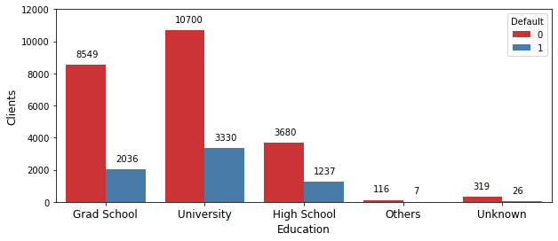

```python
plt.figure(figsize=(10,4))

ax = sns.countplot(data = df, x = 'EDUCATION', hue="Default", palette = 'Set1')

plt.xlabel("Education", fontsize= 12)
plt.ylabel("Clients", fontsize= 12)
plt.ylim(0,12000)
plt.xticks([0,1,2,3,4],['Grad School','University','High School','Others','Unknown'], fontsize = 12)

for p in ax.patches:
    ax.annotate((p.get_height()), (p.get_x()+0.10, p.get_height()+500))

plt.show()
```

DATA DENSITY

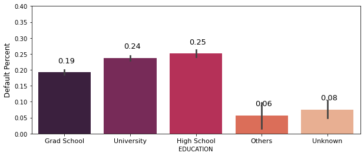

```python
plt.figure(figsize=(10,4))

ax = sns.barplot(x = "EDUCATION", y = "Default", data = df, palette = 'rocket')

plt.ylabel("Default Percent", fontsize= 12)
plt.ylim(0,0.4)
plt.xticks([0,1,2,3,4],['Grad School','University','High School','Others','Unknown'], fontsize = 11)

for p in ax.patches:
    ax.annotate("%.2f" %(p.get_height()), (p.get_x()+0.30, p.get_height()+0.03),fontsize=13)

plt.show()
```

OUTCOMES:

1. Relevance of Education Attribute values follows : Grad School <-- University <-- High School <-- Others <-- Unknown
2. Considering, just the First three values, it can easily concluded that "High Educates may ressemble a lower chance of Default"
3. And Others & Unknown have a very distinguishable lower probability

> MARITIAL STATUS V/S DEFAULT

DATA DISTRIBUTION

```python
df['MARRIAGE'].value_counts()
```

```
2    15964
1    13659
3      323
0       54
Name: MARRIAGE, dtype: int64
```

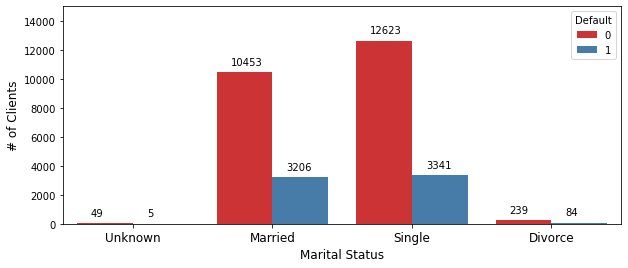

```python
plt.figure(figsize=(10,4))

ax = sns.countplot(data = df, x = 'MARRIAGE', hue="Default", palette = 'Set1')

plt.xlabel("Marital Status", fontsize= 12)
plt.ylabel("# of Clients", fontsize= 12)
plt.ylim(0,15000)
plt.xticks([0,1,2,3],['Unknown', 'Married', 'Single', 'Divorce'], fontsize = 12)

for p in ax.patches:
    ax.annotate((p.get_height()), (p.get_x()+0.10, p.get_height()+500))

plt.show()
```

DATA DENSITY

```python
df['Default'].groupby(df['MARRIAGE']).value_counts(normalize = True)
```

```
MARRIAGE  Default
0         0          0.907407
          1          0.092593
1         0          0.765283
          1          0.234717
2         0          0.790717
          1          0.209283
3         0          0.739938
          1          0.260062
Name: Default, dtype: float64
```

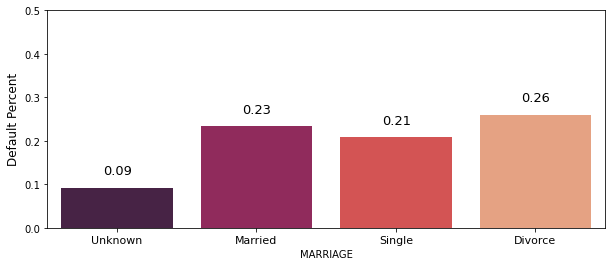

```python
plt.figure(figsize=(10,4))

ax = sns.barplot(x = "MARRIAGE", y = "Default", data = df, palette = 'rocket', ci = None)

plt.ylabel("Default Percent", fontsize= 12)
plt.ylim(0,0.5)
plt.xticks([0,1,2,3],['Unknown', 'Married', 'Single', 'Divorce'], fontsize = 11)

for p in ax.patches:
    ax.annotate("%.2f" %(p.get_height()), (p.get_x()+0.30, p.get_height()+0.03),fontsize=13)

plt.show()
```

PLOT OUTCOMES

1. Data is densely populated towards two values Married, Single
2. Again Unknown category has least probability for default
3. Among rest, Single has comparatively less probability for default

> MULTI-ATTRIBUTE DEPENDENCY

DEFAULT VALUE DEPENDENCY on SEX AND MARITIAL STATUS AS A WHOLE - DATA DISTRIBUTION

```python
df.groupby(by=['MARRIAGE', 'SEX'])['Default'].value_counts(normalize = True)
```

```
MARRIAGE  SEX  Default
0         1    0          0.857143
               1          0.142857
          2    0          0.925000
               1          0.075000
1         1    0          0.740655
               1          0.259345
          2    0          0.780375
               1          0.219625
2         1    0          0.773386
               1          0.226614
          2    0          0.802784
               1          0.197216
3         1    0          0.694656
               1          0.305344
          2    0          0.770833
               1          0.229167
Name: Default, dtype: float64
```

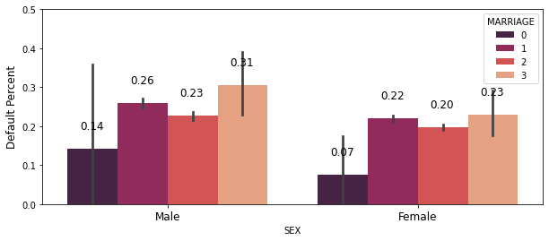

```python
plt.figure(figsize=(10,4))

ax = sns.barplot(x = "SEX", y = "Default", hue = "MARRIAGE", data = df, palette = 'rocket')

plt.ylabel("Default Percent", fontsize= 12)
plt.ylim(0,0.5)
plt.xticks([0,1],['Male', 'Female'], fontsize = 12)

for p in ax.patches:
    ax.annotate("%.2f" %(p.get_height()), (p.get_x()+0.05, p.get_height()+0.05),fontsize=12)

plt.show()
```

DEFAULT VALUE DEPENDENCY on SEX AND EDUCATION AS A WHOLE - DENSITY DISTRIBUTION

```python
df.groupby(by=[ 'SEX','EDUCATION'])['Default'].value_counts(normalize = True)
```

```
SEX  EDUCATION  Default
1    1          0          0.791915
                1          0.208085
     2          0          0.737998
                1          0.262002
     3          0          0.726131
                1          0.273869
     4          0          0.904762
                1          0.095238
     5          0          0.921875
                1          0.078125
2    1          0          0.818649
                1          0.181351
     2          0          0.777957
                1          0.222043
     3          0          0.763580
                1          0.236420
     4          0          0.962963
                1          0.037037
     5          0          0.926267
                1          0.073733
Name: Default, dtype: float64
```

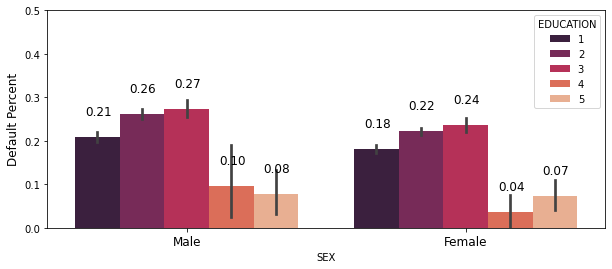

```python
plt.figure(figsize=(10,4))

ax = sns.barplot(x = "SEX", y = "Default", hue = "EDUCATION", data = df, palette = 'rocket')

plt.ylabel("Default Percent", fontsize= 12)
plt.ylim(0,0.5)
plt.xticks([0,1],['Male', 'Female'], fontsize = 12)

for p in ax.patches:
    ax.annotate("%.2f" %(p.get_height()), (p.get_x()+0.035, p.get_height()+0.05),fontsize=12)

plt.show()
```

> So, our very first outcome from Data Scrubbing, seems to be in right portion. As we can see, through multi-dependency as well attribute dependency plots, that the: *THE PROBABIITY OF DEFAULT FOR MALE IS HIGHER*

AGE V/S DEFAULT

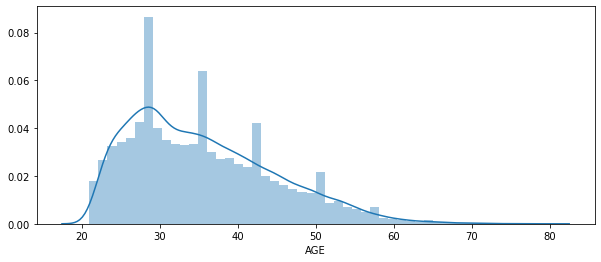

```python
plt.figure(figsize=(10,4))

sns.distplot(df['AGE'])
plt.ticklabel_format(style='plain', axis='x') #repressing scientific notation on x
plt.ylabel('')
plt.show()
```

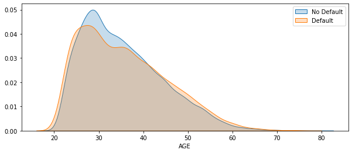

```python
plt.figure(figsize=(10,4))

sns.kdeplot(df.loc[(df['Default'] == 0), 'AGE'], label = 'No Default', shade = True)
sns.kdeplot(df.loc[(df['Default'] == 1), 'AGE'], label = 'Default', shade = True)
plt.ylabel('')
plt.legend()
plt.show()
```

> Let see the Data Distribution over Span of Age

```python
df['AgeBin'] = pd.cut(df['AGE'],[20, 25, 30, 35, 40, 45, 50, 60, 80])
print(df['AgeBin'].value_counts())
```

```
(25, 30]    7142
(30, 35]    5796
(35, 40]    4917
(20, 25]    3871
(40, 45]    3605
(45, 50]    2400
(50, 60]    1997
(60, 80]     272
Name: AgeBin, dtype: int64
```

> PROBABILITY OF DEFAULT FOR ABOVE AGE GROUPS

```python
df['Default'].groupby(df['AgeBin']).value_counts(normalize = True)
```

```
AgeBin    Default
(20, 25]  0          0.733402
          1          0.266598
(25, 30]  0          0.798516
          1          0.201484
(30, 35]  0          0.805728
          1          0.194272
(35, 40]  0          0.783811
          1          0.216189
(40, 45]  0          0.778641
          1          0.221359
(45, 50]  0          0.749583
          1          0.250417
(50, 60]  0          0.747621
          1          0.252379
(60, 80]  0          0.731618
          1          0.268382
Name: Default, dtype: float64
```

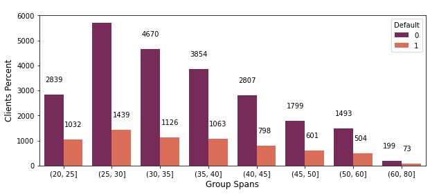

```python
plt.figure(figsize=(10,4))

df['AgeBin'] = df['AgeBin'].astype('str')
AgeBin_order = ['(20, 25]', '(25, 30]', '(30, 35]', '(35, 40]', '(40, 45]', '(45, 50]', '(50, 60]', '(60, 80]']

ax = sns.countplot(data = df, x = 'AgeBin', hue="Default", palette = 'rocket', order = AgeBin_order)

plt.xlabel("Group Spans", fontsize= 12)
plt.ylabel("Clients Percent", fontsize= 12)
plt.ylim(0,6000)

for p in ax.patches:
    ax.annotate((p.get_height()), (p.get_x()+0.02, p.get_height()+500))

plt.show()
```

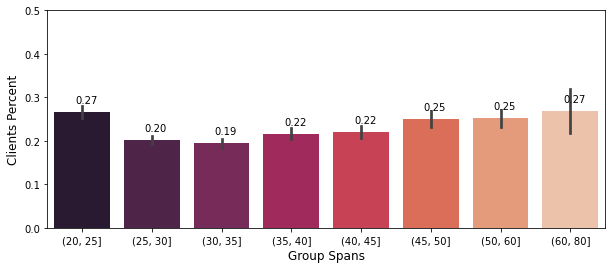

```python
plt.figure(figsize=(10,4))

ax = sns.barplot(data = df, x = 'AgeBin', y="Default", palette = 'rocket', order = AgeBin_order)

plt.xlabel("Group Spans", fontsize= 12)
plt.ylabel("Clients Percent", fontsize= 12)
plt.ylim(0,0.5)

for p in ax.patches:
    ax.annotate('%.2f' %(p.get_height()), (p.get_x()+0.3, p.get_height()+0.02))

plt.show()
```

> The least probability of default are registered around 30-35 years span Users, while the highest occur at the 20-25 and 60+ span group.

> LIMIT_BAL

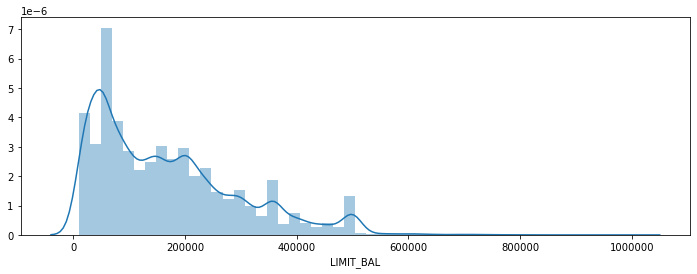

```python
plt.figure(figsize=(12,4))

sns.distplot(df['LIMIT_BAL'])
plt.ticklabel_format(style='plain', axis='x') #repressing scientific notation on x
plt.ylabel('')
plt.show()
```

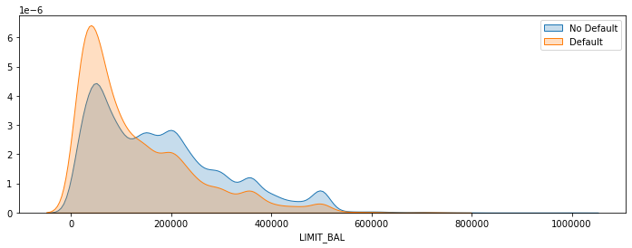

```python
plt.figure(figsize=(12,4))

sns.kdeplot(df.loc[(df['Default'] == 0), 'LIMIT_BAL'], label = 'No Default', shade = True)
sns.kdeplot(df.loc[(df['Default'] == 1), 'LIMIT_BAL'], label = 'Default', shade = True)
plt.ticklabel_format(style='plain', axis='x') #repressing scientific notation on x
plt.ylabel('')
plt.legend()
plt.show()
```

> Lets see Numerical Distribution of LIMIT_BAL

```python
df['Limit_Bal_Bin'] = pd.cut(df['LIMIT_BAL'],[1000, 50000, 100000, 150000, 200000, 250000, 300000, 400000, 500000, 1100000])
print(df['Limit_Bal_Bin'].value_counts())
```

```
(1000, 50000]        7676
(50000, 100000]      4822
(150000, 200000]     3978
(100000, 150000]     3902
(200000, 250000]     2905
(300000, 400000]     2759
(250000, 300000]     2154
(400000, 500000]     1598
(500000, 1100000]     206
Name: Limit_Bal_Bin, dtype: int64
```

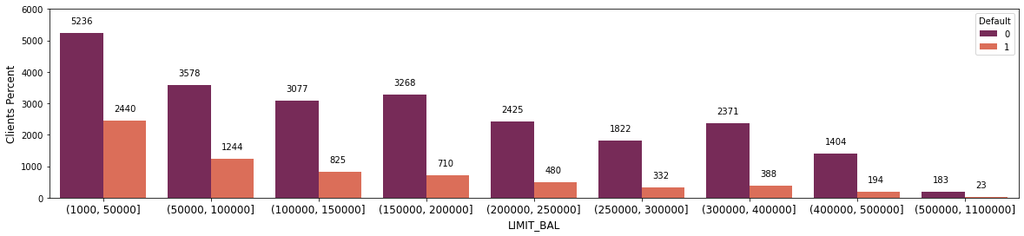

```python
plt.figure(figsize=(20,4))

df['Limit_Bal_Bin'] = df['Limit_Bal_Bin'].astype('str')
LimitBin_order = ['(1000, 50000]', '(50000, 100000]', '(100000, 150000]', '(150000, 200000]',
                '(200000, 250000]', '(250000, 300000]', '(300000, 400000]', '(400000, 500000]', '(500000, 1100000]']

ax = sns.countplot(data = df, x = 'Limit_Bal_Bin', hue="Default", palette = 'rocket', order = LimitBin_order)

plt.xlabel("LIMIT_BAL", fontsize= 12)
plt.ylabel("Clients Percent", fontsize= 12)
plt.ylim(0,6000)
ax.tick_params(axis="x", labelsize= 12)

for p in ax.patches:
    ax.annotate((p.get_height()), (p.get_x()+0.1, p.get_height()+300))

plt.show()
```

> Probablity Distribution of LIMIT_BAL for DEFAULT

```python
df['Default'].groupby(df['Limit_Bal_Bin']).value_counts(normalize = True)
```

```
Limit_Bal_Bin      Default
(1000, 50000]      0          0.682126
                   1          0.317874
(100000, 150000]   0          0.788570
                   1          0.211430
(150000, 200000]   0          0.821518
                   1          0.178482
(200000, 250000]   0          0.834768
                   1          0.165232
(250000, 300000]   0          0.845868
                   1          0.154132
(300000, 400000]   0          0.859369
                   1          0.140631
(400000, 500000]   0          0.878598
                   1          0.121402
(50000, 100000]    0          0.742016
                   1          0.257984
(500000, 1100000]  0          0.888350
                   1          0.111650
Name: Default, dtype: float64
```

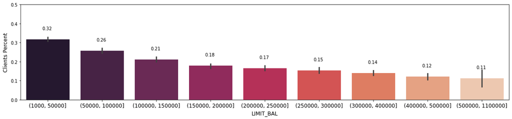

```python
plt.figure(figsize=(20,4))

df['Limit_Bal_Bin'] = df['Limit_Bal_Bin'].astype('str')
LimitBin_order = ['(1000, 50000]', '(50000, 100000]', '(100000, 150000]', '(150000, 200000]',
                '(200000, 250000]', '(250000, 300000]', '(300000, 400000]', '(400000, 500000]', '(500000, 1100000]']

ax = sns.barplot(data = df, x = 'Limit_Bal_Bin', y="Default", palette = 'rocket', order = LimitBin_order)

plt.xlabel("LIMIT_BAL", fontsize= 12)
plt.ylabel("Clients Percent", fontsize= 12)
plt.ylim(0,0.5)
ax.tick_params(axis="x", labelsize= 12)

for p in ax.patches:
    ax.annotate('%.2f' %(p.get_height()), (p.get_x()+0.3, p.get_height()+0.05))

plt.show()
```

- CONCLUSIONS FROM PLOTS

> It is clear from plot that the User with less credit limit has higher Default positive probability.

> MEAN LIMT_BAL FOR ATTRIBUTES

> SEX ATTRIBUTE V/S LIMIT_BAL ATTRIBUTE

```python
df.groupby('SEX')['LIMIT_BAL'].mean()
```

```
SEX
1    163519.825034
2    170086.462014
Name: LIMIT_BAL, dtype: float64
```

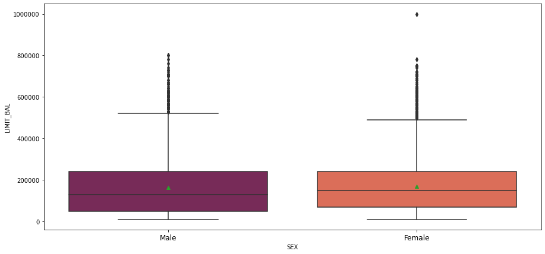

```python
plt.figure(figsize=(15,7))

sns.boxplot(x = "SEX", y = "LIMIT_BAL",data = df, palette = 'rocket', showmeans=True)

plt.ticklabel_format(style='plain', axis='y') #repressing scientific notation
plt.xticks([0,1],['Male', 'Female'], fontsize = 12)

plt.show()
```

> EDUCATION ATTRIBUTE V/S LIMIT_BAL ATTRIBUTE

```python
df.groupby('EDUCATION')['LIMIT_BAL'].mean()
```

```
EDUCATION
1    212956.069910
2    147062.437634
3    126550.270490
4    220894.308943
5    167205.797101
Name: LIMIT_BAL, dtype: float64
```

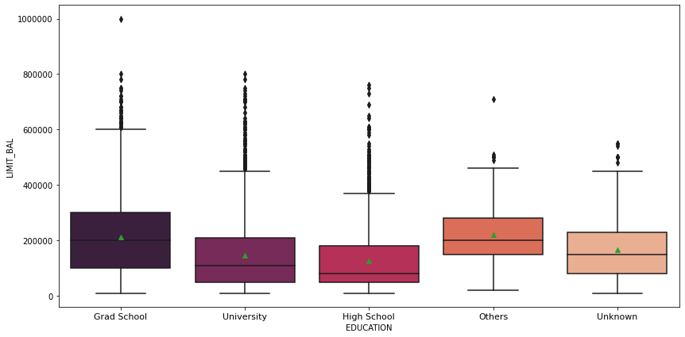

```python
plt.figure(figsize=(14,7))

sns.boxplot(x = "EDUCATION", y = "LIMIT_BAL", data = df, palette = 'rocket', showmeans=True, )

plt.ticklabel_format(style='plain', axis='y') #repressing scientific notation
plt.xticks([0,1,2,3,4],['Grad School','University','High School','Others','Unknown'], fontsize = 11)

plt.show()
```

> MARITIAL STATUS V/S LIMIT_BAL

```python
df.groupby('MARRIAGE')['LIMIT_BAL'].mean()
```

```
MARRIAGE
0    132962.962963
1    182200.893184
2    156413.660737
3     98080.495356
Name: LIMIT_BAL, dtype: float64
```

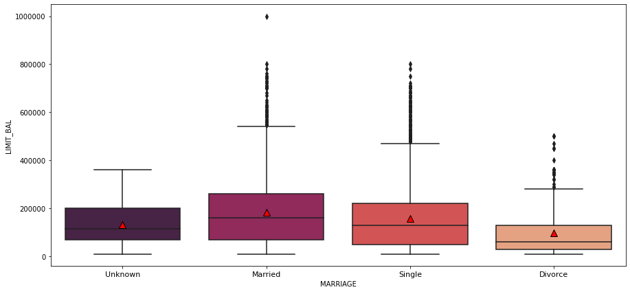

```python
plt.figure(figsize=(15,7))

sns.boxplot(x = "MARRIAGE", y = "LIMIT_BAL", data = df, palette = 'rocket', showmeans=True,
            meanprops={"markerfacecolor":"red",  "markeredgecolor":"black", "markersize":"10"})

plt.ticklabel_format(style='plain', axis='y') #repressing scientific notation
plt.xticks([0,1,2,3],['Unknown', 'Married', 'Single', 'Divorce'], fontsize = 11)

plt.show()
```

> AGE GROUPS V/S LIMIT_BAL

```python
df.groupby('AgeBin')['LIMIT_BAL'].mean()
```

```
AgeBin
(20, 25]     73763.885301
(25, 30]    164320.918510
(30, 35]    197688.060732
(35, 40]    196780.557250
(40, 45]    184157.470180
(45, 50]    172955.000000
(50, 60]    159349.023535
(60, 80]    201617.647059
Name: LIMIT_BAL, dtype: float64
```

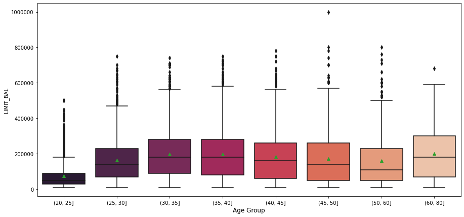

```python
plt.figure(figsize=(15, 7))

sns.boxplot(x = "AgeBin", y = "LIMIT_BAL",data = df, palette = 'rocket', order = AgeBin_order, showmeans=True)

plt.ticklabel_format(style='plain', axis='y') #repressing scientific notation
plt.xlabel("Age Group", fontsize= 12)

plt.show()
```

> Overall FEMALE has been seem to have a higher avg. credit limit i.e. LIMIT_BAL

> ATTRIBUTE DEPENDENCY W.R.T SEX ATTRIBUTE FOR LIMIT_BAL

> EDUCATION

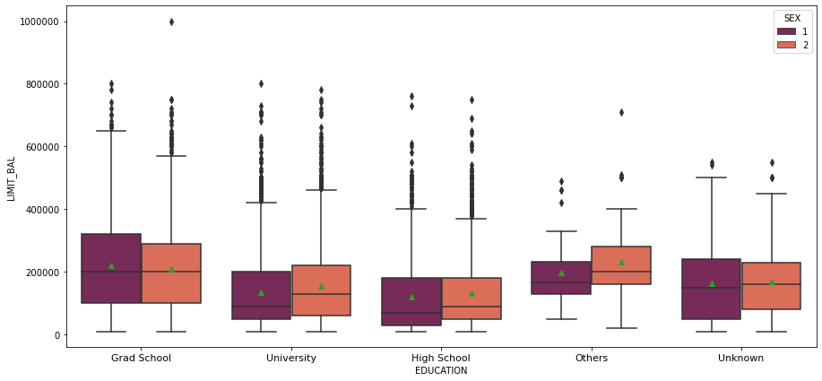

```python
plt.figure(figsize=(15,7))

sns.boxplot(x = "EDUCATION", y = "LIMIT_BAL", hue = 'SEX', data = df, palette = 'rocket', showmeans=True)

plt.ticklabel_format(style='plain', axis='y') #repressing scientific notation
plt.xticks([0,1,2,3,4],['Grad School','University','High School','Others','Unknown'], fontsize = 11)

plt.show()
```

> MARITIAL STATUS

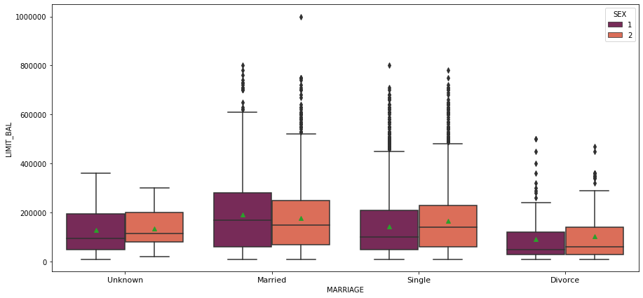

```python
plt.figure(figsize=(15,7))

sns.boxplot(x = "MARRIAGE", y = "LIMIT_BAL", hue = 'SEX', data = df, palette = 'rocket', showmeans=True)

plt.ticklabel_format(style='plain', axis='y') #repressing scientific notation
plt.xticks([0,1,2,3],['Unknown', 'Married', 'Single', 'Divorce'], fontsize = 11)

plt.show()
```

> AGE GROUPS - AgeBin

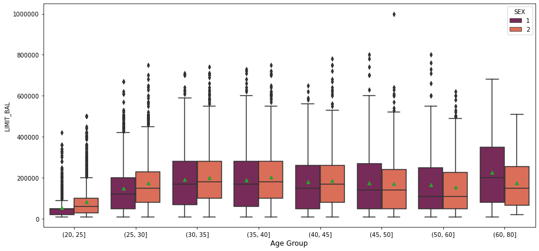

```python
plt.figure(figsize=(15,7))

sns.boxplot(x = "AgeBin", y = "LIMIT_BAL", hue = 'SEX', data = df, palette = 'rocket', order = AgeBin_order, showmeans=True)

plt.ticklabel_format(style='plain', axis='y') #repressing scientific notation
plt.xlabel("Age Group", fontsize= 12)

plt.show()
```

> ATTRIBUTE DEPENDENCY W.R.T EDUCATION ATTRIBUTE FOR LIMIT_BAL

> SEX ATTRIBUTE

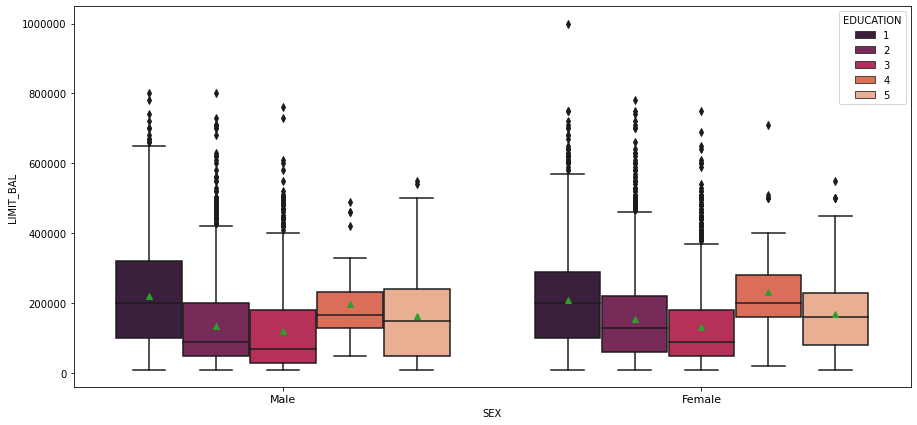

```python
plt.figure(figsize=(15,7))

sns.boxplot(hue = "EDUCATION", y = "LIMIT_BAL", x = 'SEX', data = df, palette = 'rocket', showmeans=True)

plt.ticklabel_format(style='plain', axis='y') #repressing scientific notation
plt.xticks([0,1],['Male','Female'], fontsize = 11)

plt.show()
```

> MARITIAL STATUS

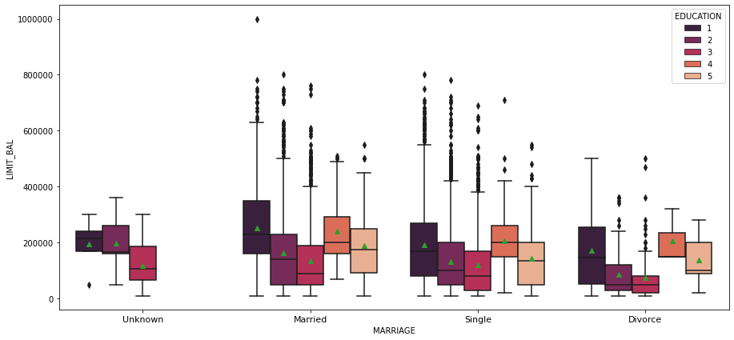

```python
plt.figure(figsize=(15,7))

sns.boxplot(x = "MARRIAGE", y = "LIMIT_BAL", hue = 'EDUCATION', data = df, palette = 'rocket', showmeans=True)

plt.ticklabel_format(style='plain', axis='y') #repressing scientific notation
plt.xticks([0,1,2,3],['Unknown', 'Married', 'Single', 'Divorce'], fontsize = 11)

plt.show()
```

> AGE GROUPS

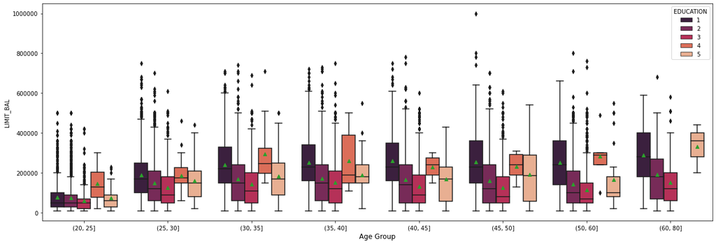

```python
plt.figure(figsize=(21,7))

sns.boxplot(x = "AgeBin", y = "LIMIT_BAL", hue = 'EDUCATION', data = df, palette = 'rocket', order = AgeBin_order, showmeans=True)

plt.ticklabel_format(style='plain', axis='y') #repressing scientific notation
plt.xlabel("Age Group", fontsize= 12)

plt.show()
```

> ATTRIBUTE DEPENDENCY W.R.T MARITIAL STATUS FOR LIMIT_BAL